# Análisis del Rendimiento Escolar

América Itzel Reyes Alatorre

Introducción: Este análisis explora cómo diversos factores socioeducativos influyen en el rendimiento académico de estudiantes en las áreas de matemáticas, lectura y escritura. El estudio se basa en el dataset “Students Performance in Exams” disponible en Kaggle, que contiene información de 1,000 estudiantes.

Objetivos principales: -Analizar el impacto del género, nivel educativo de los padres y tipo de almuerzo en los puntajes académicos

-Identificar diferencias significativas entre grupos

-Visualizar patrones y relaciones clave en los datos

```r
# Cargar librerías
library(dplyr)
```

```r
library(ggplot2)

# 1. Cargar datos
data <- read.csv("StudentsPerformance.csv")

# 2. Exploración inicial
summary(data)
```

```
##     gender          race.ethnicity     parental.level.of.education
##  Length:1000        Length:1000        Length:1000
##  Class :character   Class :character   Class :character
##  Mode  :character   Mode  :character   Mode  :character
##
##
##
##     lunch           test.preparation.course   math.score     reading.score
##  Length:1000        Length:1000             Min.   :  0.00   Min.   : 17.00
##  Class :character   Class :character        1st Qu.: 57.00   1st Qu.: 59.00
##  Mode  :character   Mode  :character        Median : 66.00   Median : 70.00
##                                             Mean   : 66.09   Mean   : 69.17
##                                             3rd Qu.: 77.00   3rd Qu.: 79.00
##                                             Max.   :100.00   Max.   :100.00
##  writing.score
##  Min.   : 10.00
##  1st Qu.: 57.75
##  Median : 69.00
##  Mean   : 68.05
##  3rd Qu.: 79.00
##  Max.   :100.00
```

```r
str(data)
```

```
## 'data.frame':    1000 obs. of  8 variables:
##  $ gender                     : chr  "female" "female" "female" "male" ...
##  $ race.ethnicity             : chr  "group B" "group C" "group B" "group A" ...
##  $ parental.level.of.education: chr  "bachelor's degree" "some college" "master's degree" "associate's degree" ...
##  $ lunch                      : chr  "standard" "standard" "standard" "free/reduced" ...
##  $ test.preparation.course    : chr  "none" "completed" "none" "none" ...
##  $ math.score                 : int  72 69 90 47 76 71 88 40 64 38 ...
##  $ reading.score              : int  72 90 95 57 78 83 95 43 64 60 ...
##  $ writing.score              : int  74 88 93 44 75 78 92 39 67 50 ...
```

```r
# 3. Manejo de valores faltantes
sum(is.na(data))
```

```
## [1] 0
```

```r
# Opcional: Eliminar filas con NAs
data_clean <- na.omit(data)
```

A continuación se realizan las transformaciones con dplyr, convirtiendo variables categóricas a factores, creando igual nuevas variables para su posterior manipulación.

```r
# 4. Transformaciones con dplyr
data_clean <- data %>%
  rename(
    parental_education = `parental.level.of.education`,
    lunch_type = lunch
  ) %>%
  mutate(
    gender = as.factor(gender),
    parental_education = factor(parental_education,
                                levels = c("some high school", "high school", "some college",
                                           "associate's degree", "bachelor's degree", "master's degree")),
    lunch_type = as.factor(lunch_type),
    avg_score = (math.score + reading.score + writing.score) / 3
  )

# 5. Estadísticos por grupo
data_clean %>%
  group_by(gender) %>%
  summarise(
    mean_math = mean(math.score),
    median_math = median(math.score)
  )
```

```
## # A tibble: 2 × 3
##   gender mean_math median_math
##   <fct>      <dbl>       <dbl>
## 1 female      63.6          65
## 2 male        68.7          69
```

```r
data_clean %>%
  group_by(lunch_type) %>%
  summarise(
    mean_math = mean(math.score),
    mean_reading = mean(reading.score),
    mean_writing = mean(writing.score),
    count = n()
  )
```

```
## # A tibble: 2 × 5
##   lunch_type   mean_math mean_reading mean_writing count
##   <fct>            <dbl>        <dbl>        <dbl> <int>
## 1 free/reduced      58.9         64.7         63.0   355
## 2 standard          70.0         71.7         70.8   645
```

Ahora creamos visualizaciones que exploren relaciones entre variables clave tomando como referencia el cuestionamiento inicial

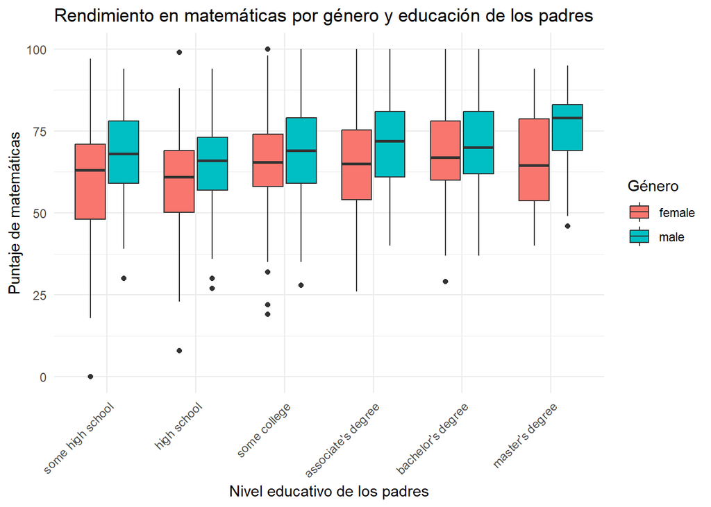

```r
# 6. Visualizaciones

ggplot(data_clean, aes(x = parental_education, y = math.score, fill = gender)) +
  geom_boxplot() +
  labs(
    title = "Rendimiento en matemáticas por género y educación de los padres",
    x = "Nivel educativo de los padres",
    y = "Puntaje de matemáticas",
    fill = "Género"
  ) +
  theme_minimal() +
  theme(axis.text.x = element_text(angle = 45, hjust = 1))
```

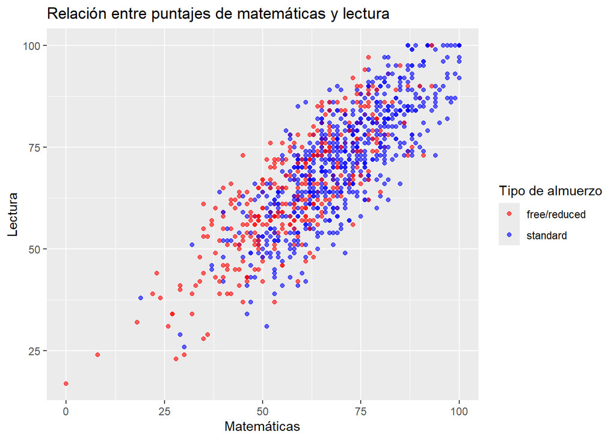

```r
ggplot(data_clean, aes(x = math.score, y = reading.score, color = lunch_type)) +
  geom_point(alpha = 0.6) +
  labs(
    title = "Relación entre puntajes de matemáticas y lectura",
    x = "Matemáticas",
    y = "Lectura",
    color = "Tipo de almuerzo"
  ) +
  scale_color_manual(values = c("red", "blue"))
```

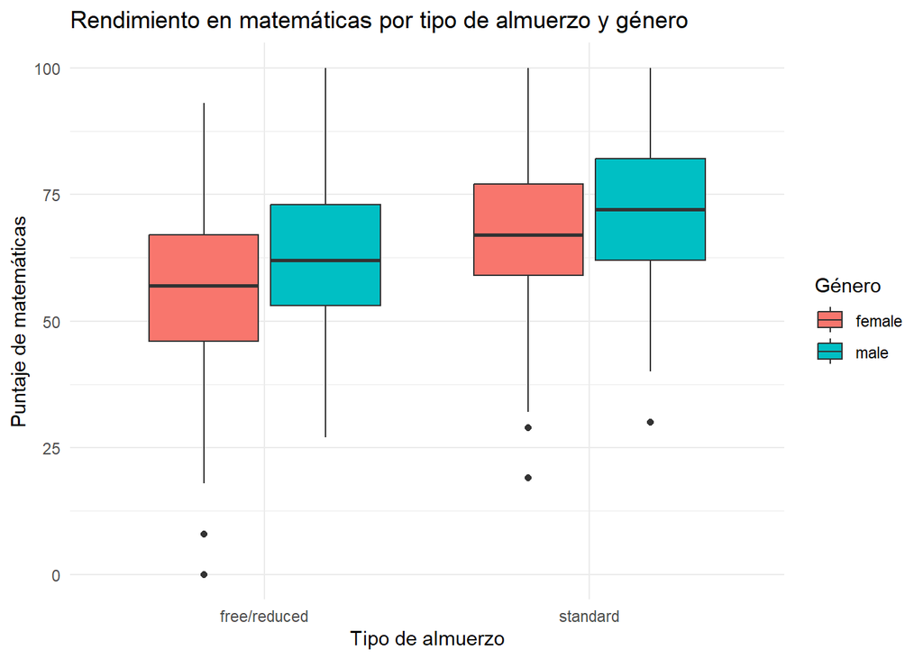

```r
ggplot(data_clean, aes(x = lunch_type, y = math.score, fill = gender)) +
  geom_boxplot() +
  labs(
    title = "Rendimiento en matemáticas por tipo de almuerzo y género",
    x = "Tipo de almuerzo",
    y = "Puntaje de matemáticas",
    fill = "Género"
  ) +
  theme_minimal()
```

Conclusiones: De acuerdo con los hallazgos del análisis, se identificaron tres factores clave que influyen en el desempeño estudiantil: el tipo de almuerzo, el nivel educativo de los padres y las diferencias por género en áreas específicas. Para optimizar el rendimiento académico en la institución, se recomienda implementar las siguientes estrategias:

En primer lugar, dado que los estudiantes con almuerzo “standard” obtienen mejores resultados, se sugiere evaluar y fortalecer los programas de alimentación escolar, especialmente para aquellos en situación vulnerable. Esto podría incluir la ampliación de becas de comedor, la mejora nutricional de los menús o la implementación de desayunos escolares, asegurando que todos los alumnos tengan acceso a una alimentación equilibrada. Estudios respaldan que una nutrición adecuada está directamente vinculada a la concentración y el rendimiento cognitivo.

En segundo lugar, la correlación entre el nivel educativo de los padres y el éxito académico de los estudiantes indica la necesidad de programas que involucren a las familias en el proceso educativo. Se podrían organizar talleres para padres sobre técnicas de apoyo en el hogar, tutorías conjuntas o acceso a recursos educativos digitales. Además, para abordar las diferencias por género —como el menor desempeño de las mujeres en matemáticas—, se recomienda fomentar mentorías con enfoque de género, clubes de ciencias dirigidos a mujeres y capacitación docente en metodologías inclusivas que reduzcan estereotipos.

Finalmente, un enfoque integral que combine políticas nutricionales, participación familiar y equidad de género permitirá no solo mejorar los resultados académicos, sino también reducir brechas socioeconómicas y promover un ambiente educativo más inclusivo y equitativo. La institución podría medir el impacto de estas intervenciones mediante evaluaciones periódicas, ajustando las estrategias según los resultados obtenidos.